# Identificando dados com coordenadas correspondentes ao mar

Nesse tutorial aprenderemos a identificar coordenadas fora do continente em dados do SpeciesLink.

Como exemplo, usaremos os registros de Apocynaceae do SpeciesLink (https://specieslink.net/).

### Instalação e carregamento dos pacotes

Vamos precisar dos pacotes **openxlsx**, para ler arquivos Excel, **raster**, para manusear formatos de arquivos SIG, e **CoordinateCleaner** para filtrar os registros geográficos.

- **openxlsx** (Schauberger *et al*., 2020): https://ycphs.github.io/openxlsx/index.html
- **raster** (Hijmans, 2021): https://CRAN.R-project.org/package=raster
- **CoordinateCleaner** (Zizka *et al*., 2019): https://github.com/ropensci/CoordinateCleaner

Instalamos os pacotes com o comando `install.packages()`:

```r
install.packages(c("openxlsx", "raster", "CoordinateCleaner"), repos="http //cran.us.r-project.org")
```

Carregamos os pacotes com o comando `library()`:

```r
library("openxlsx")
library("raster")
library("CoordinateCleaner")
```

### Setup do ambiente de trabalho e carregamento dos dados

Vamos definir o diretório de trabalho, onde estará a *planilha* baixada do **SpeciesLink**. Para isso, usamos a função `set.wd()`.

```r
setwd("/Users/jdvidal/Desktop/INCT/")
```

Vamos usar a função `read.xlsx()` e `read.csv()` para ler a planilha.

```r
records <- read.xlsx("/Users/jdvidal/Desktop/INCT/speciesLink-20210920072313-0004598.xlsx")
```

E a função shapefile para ler o shapefile com os limites geográficos e nomes dos países do mundo.

```r
countries <- shapefile("/Users/jdvidal/Desktop/INCT/ne_10m_admin_0_countries/ne_10m_admin_0_countries.shp")
```

### Preparando o conjunto de dados

```r
head(records)
```

```
##      datelastmodified basisofrecord institutioncode collectioncode
## 1 2021-05-17T15:42:16             S         UNICAMP            UEC
## 2 2021-05-17T15:42:16             S         UNICAMP            UEC
## 3 2021-05-17T15:42:16             S         UNICAMP            UEC
## 4 2021-05-17T15:42:16             S         UNICAMP            UEC
## 5 2021-05-17T15:41:32             S         UNICAMP            UEC
## 6 2021-05-17T15:42:27             S         UNICAMP            UEC
##   catalognumber kingdom        phylum taxonclass ordem      family       genus
## 1        162370 Plantae Magnoliopsida                  Apocynaceae    Plumeria
## 2        162371 Plantae Magnoliopsida                  Apocynaceae    Plumeria
## 3        129167 Plantae Magnoliopsida                  Apocynaceae    Plumeria
## 4        129169 Plantae Magnoliopsida                  Apocynaceae    Plumeria
## 5         51233 Plantae Magnoliopsida                  Apocynaceae Forsteronia
## 6         97372 Plantae Magnoliopsida                  Apocynaceae  Schubertia
##   species subspecies   scientificname scientificnameauthor typestatus
## 1                            Plumeria                   L.
## 2                            Plumeria                   L.
## 3 inodora            Plumeria inodora
## 4   rubra              Plumeria rubra                   L.
## 5                         Forsteronia
## 6                          Schubertia
##   yearcollected monthcollected daycollected
## 1          2007             05           15
## 2          2007             05           15
## 3          2001             10           10
## 4          2002             01           04
## 5          1986             01           09
## 6          1997             02           21
##                                       collector collectornumber fieldnumber
## 1                     Fornari, ARS; Sanches, MA            s.n.
## 2                     Fornari, ARS; Sanches, MA            s.n.
## 3                                      Gomes, M             725
## 4                                      Gomes, M             732
## 5                                   Pereira, OJ             847
## 6 Nave, AG; Carneiro, PHM; Dário, FR; Lopes, RF            1144
##   julianday timeofday identifiedby yearidentified monthidentified dayidentified
## 1                     Fornari, ARS           2007              05
## 2                     Fornari, ARS           2007              05
## 3                        Spina, AP           2002              12
## 4                        Spina, AP           2002              12
```

[output cut: 64 more lines]

```
## 6
##   geneticallymodified genotype mutant race alternatestate strainproperties
## 1
## 2
## 3
## 4
## 5
## 6
##   strainapplications formofsupply restrictions biologicalrisks pathogenicity
## 1
## 2
## 3
## 4
## 5
## 6
```

Aqui temos nosso primeiro problema.

```r
class(records$latitude)
```

```
## [1] "character"
```

Os valores de coordenadas na coluna *records$latitude* estão sendo interpretados como texto. Para convertê-los para números, usamos a função `as.numeric()`.

```r
records$latitude <- as.numeric(records$latitude)
records$longitude <- as.numeric(records$longitude)
```

Vamos nos certificar de usar apenas dados que possuam informação geográfica. Para isso, usamos `complete.cases()` para selecionar apenas linhas cujos valores estão completos para a coluna “latitude”.

```r
records <- records[complete.cases(records$latitude),]
```

Vamos extrair os pontos que caem no mar com o CoordinateCleaner. Usamos a função `cc_sea()` para remover coordenadas que caírem no mar. Essa função leva três argumentos, sendo o primeiro deles o objeto data.frame com as ocorrências, o segundo argumento *lon* referente ao nome da coluna contendo os valores de longitude e o terceiro argumento *lat*, cujo valor corresponde ao nome da coluna contendo os valores de latitude.

```r
records_filtered <- cc_sea(records, lon = "longitude", lat="latitude")
```

```
## Testing sea coordinates
```

```
## Removed 73 records.
```

Para visualizar os pontos problemáticos, selecionamos todos os valores da planilha original que não estão mais na planilha filtrada.

```r
list_sea_mismatches <- records[!records$catalognumber%in%records_filtered$catalognumber,]
nrow(list_sea_mismatches)
```

```
## [1] 71
```

### Plotando os pontos em um mapa

Vamos agora converter o data.frame *records* para um objeto espacial. Para isso, usamos a função `coordinates()` e declaramos que as colunas *longitude* e *latitude* correspondem aos valores de coordenadas x e y com o argumento `~longitude+latitude`.

```r
coordinates(records) <- ~longitude+latitude
coordinates(list_sea_mismatches) <- ~longitude+latitude
```

Uma vez atribuídas as coordenadas, podemos plotar os dados problemáticos com a função points. Vamos usar o shapefile `countries` como base. Como queremos apenas a América do Sul no nosso mapa, vamos selecionar dentro do shapefile `countries` os componentes cujo campo `CONTINENT` seja igual a `"South America"`.

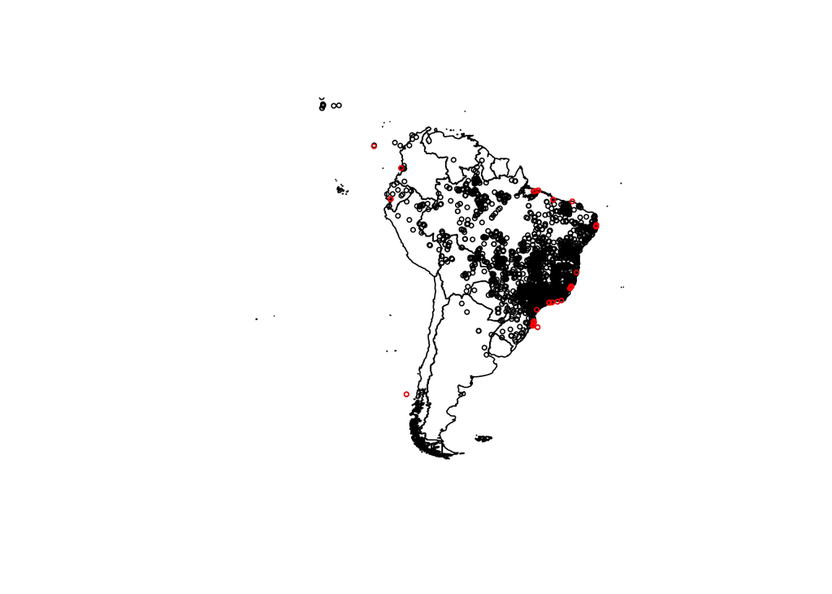

```r
plot(countries[countries$CONTINENT=="South America",])
points(records, cex=0.5)
points(list_sea_mismatches, cex=0.5, col="red")
```

Existem 71 dados com coordenadas caindo no oceano. Nós podemos corrigir estes valores individualmente através das etiquetas originais.

Por fim, salvamos estes dados num arquivo `xlsx` com a função `write.xlsx()`.

```r
write.xlsx(list_sea_mismatches, "/Users/jdvidal/Desktop/INCT/Results_ocean_records.xlsx")
```